# Lesson 7 - Data Frames III

Stats 20 – Section 1 – Vivian Lew

Due 7/14/2020 by 11:59pm PDT

# 1. Joins (or merges)

Quick review (this is covered in Week 2 on data) – the value of this skill is immense as the results of joins has the power to transform two separate datasets into something greater than their sum.

This diagram covers the fundamental types, just substitute the word table for data frame:

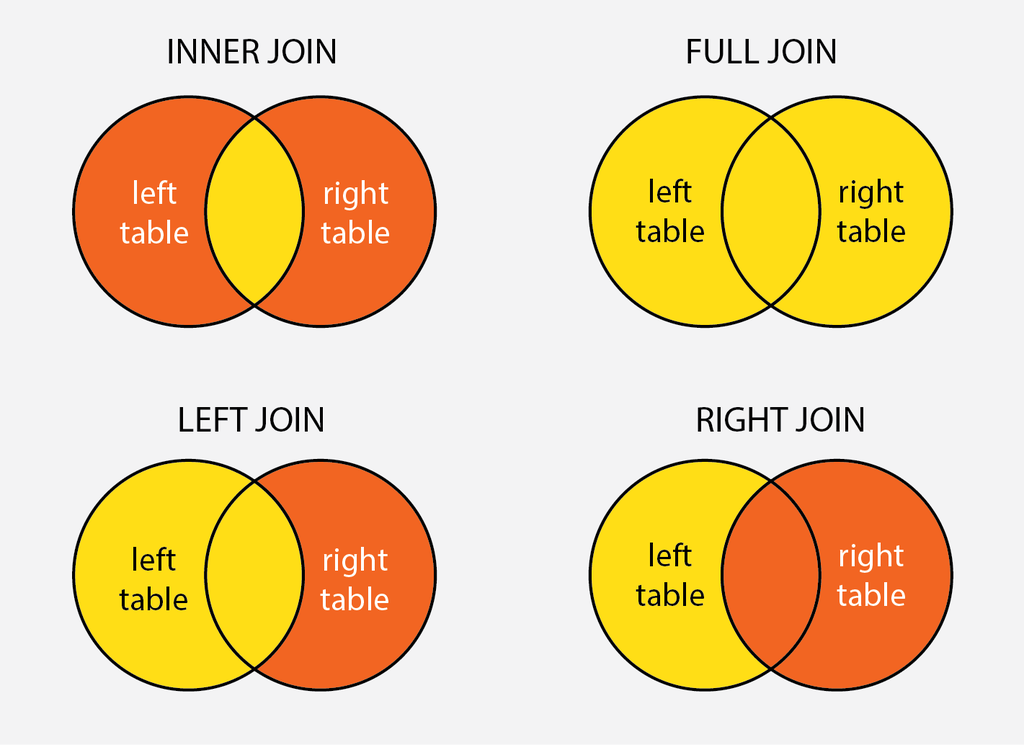

# 2. Inner joins/Merges

The dataset STmostrecent.csv has information at the state level for Covid-19 cases and deaths at the state level for the United States as of Jul 5, 2020.

The dataset STdensity.csv has information at the state level for population size, population density, and area as measured on July 1, 2015. While there is a 5 year difference in the measurement of the two datasets, we will assume it doesn’t matter and that the values have been unchanging…

By now, you should know how to import both of these into R for further analysis. If you don’t, you shouldn’t be working on lesson 7 and should review an earlier lesson (like lesson 5)

## Stop and Think

### A. If we could combine these two datasets – what kinds of questions could we ask/answer regarding Covid-19? Can you think up a question and submit it for part A?

I’m going to think of question and to help me answer that question I will need to calculate a Covid-19 infection rate for each state (divide the population size by one hundred thousand this will be called the quotient. Then I will divide the number of cases by the quotient. This gives the rate of Covid-19 cases per 100,000 people.) By showing you the steps, I hope this will help you to answer your question using data.

## Combining the two datasets – inner join/merge

The variables used to join each pair of data frames are called keys. A key is a variable (or multiple variables) that can uniquely identify an observation. In our example here, one variable (state) is enough to uniquely identify an observation. Let’s examine the contents of each data set:

```r
library(DT) ## gives us nicely formatted tables for viewing in a web browser
datatable(STmostrecent)
```

|  | date | state | fips | cases | deaths |
| --- | --- | --- | --- | --- | --- |
| 1 | 2020-07-05 | Alabama | 01 | 43953 | 1007 |
| 2 | 2020-07-05 | Alaska | 02 | 1371 | 14 |
| 3 | 2020-07-05 | Arizona | 04 | 98126 | 1829 |
| 4 | 2020-07-05 | Arkansas | 05 | 23814 | 287 |
| 5 | 2020-07-05 | California | 06 | 271587 | 6369 |
| 6 | 2020-07-05 | Colorado | 08 | 34100 | 1703 |
| 7 | 2020-07-05 | Connecticut | 09 | 46717 | 4335 |
| 8 | 2020-07-05 | Delaware | 10 | 12128 | 512 |
| 9 | 2020-07-05 | District of Columbia | 11 | 10482 | 559 |
| 10 | 2020-07-05 | Florida | 12 | 200103 | 3730 |

[output cut: 45 more lines]

and

```r
datatable(STdensity)
```

|  | state | PopDenSQMI | PopDenSQKm | Population | AreaSQMI | AreaSQKm |
| --- | --- | --- | --- | --- | --- | --- |
| 1 | District of Columbia | 11011 | 4251 | 672228 | 61 | 158 |
| 2 | New Jersey | 1218 | 470 | 8958013 | 7,354 | 19046.8 |
| 3 | Puerto Rico | 1046 | 404 | 3680058 | 3,515 | 9103.8 |
| 4 | Rhode Island | 1021 | 394 | 1056298 | 1,034 | 2678 |
| 5 | Massachusetts | 871 | 336 | 6794422 | 7,800 | 20201.9 |
| 6 | Guam | 808 | 314 | 169885 | 210 | 543.9 |
| 7 | Virgin Islands | 799 | 308 | 106906 | 134 | 347.1 |
| 8 | Connecticut | 741 | 286 | 3590886 | 4,842 | 12540.7 |
| 9 | American Samoa | 721 | 279 | 55538 | 77 | 199.4 |
| 10 | Maryland | 618 | 238 | 6006401 | 9,707 | 25141 |

[output cut: 46 more lines]

So we have the cases in one dataset and the population in another. Combining these two is easy, we would like the intersection of the two data frames so an inner_join (from dplyr) works well:

```r
library(dplyr)
combined <- inner_join(STmostrecent, STdensity, by = "state")
datatable(combined)
```

|  | date | state | fips | cases | deaths | PopDenSQMI | PopDenSQKm | Population | AreaSQMI | AreaSQKm |
| --- | --- | --- | --- | --- | --- | --- | --- | --- | --- | --- |
| 1 | 2020-07-05 | Alabama | 01 | 43953 | 1007 | 95 | 37 | 4858979 | 50,645 | 131169.9 |
| 2 | 2020-07-05 | Alaska | 02 | 1371 | 14 | 1 | 0 | 738432 | 570,641 | 1477953.4 |
| 3 | 2020-07-05 | Arizona | 04 | 98126 | 1829 | 60 | 23 | 6828065 | 113,594 | 294207.1 |
| 4 | 2020-07-05 | Arkansas | 05 | 23814 | 287 | 57 | 22 | 2978204 | 52,035 | 134770 |
| 5 | 2020-07-05 | California | 06 | 271587 | 6369 | 251 | 97 | 39144818 | 155,959[5] | 403932 |
| 6 | 2020-07-05 | Colorado | 08 | 34100 | 1703 | 52 | 20 | 5456574 | 103,642 | 268431.5 |
| 7 | 2020-07-05 | Connecticut | 09 | 46717 | 4335 | 741 | 286 | 3590886 | 4,842 | 12540.7 |
| 8 | 2020-07-05 | Delaware | 10 | 12128 | 512 | 485 | 187 | 945934 | 1,949 | 5047.9 |
| 9 | 2020-07-05 | District of Columbia | 11 | 10482 | 559 | 11011 | 4251 | 672228 | 61 | 158 |
| 10 | 2020-07-05 | Florida | 12 | 200103 | 3730 | 378 | 145 | 20271272 | 53,625 | 138888.1 |

[output cut: 45 more lines]

almost there, now we just need to calculate our rate using our combined data:

```r
combined <- combined %>%
    mutate(infrate = round(cases/(Population/100000), digits = 2))
datatable(combined)
```

|  | date | state | fips | cases | deaths | PopDenSQMI | PopDenSQKm | Population | AreaSQMI | AreaSQKm | infrate |
| --- | --- | --- | --- | --- | --- | --- | --- | --- | --- | --- | --- |
| 1 | 2020-07-05 | Alabama | 01 | 43953 | 1007 | 95 | 37 | 4858979 | 50,645 | 131169.9 | 904.57 |
| 2 | 2020-07-05 | Alaska | 02 | 1371 | 14 | 1 | 0 | 738432 | 570,641 | 1477953.4 | 185.66 |
| 3 | 2020-07-05 | Arizona | 04 | 98126 | 1829 | 60 | 23 | 6828065 | 113,594 | 294207.1 | 1437.1 |
| 4 | 2020-07-05 | Arkansas | 05 | 23814 | 287 | 57 | 22 | 2978204 | 52,035 | 134770 | 799.61 |
| 5 | 2020-07-05 | California | 06 | 271587 | 6369 | 251 | 97 | 39144818 | 155,959[5] | 403932 | 693.8 |
| 6 | 2020-07-05 | Colorado | 08 | 34100 | 1703 | 52 | 20 | 5456574 | 103,642 | 268431.5 | 624.93 |
| 7 | 2020-07-05 | Connecticut | 09 | 46717 | 4335 | 741 | 286 | 3590886 | 4,842 | 12540.7 | 1300.99 |
| 8 | 2020-07-05 | Delaware | 10 | 12128 | 512 | 485 | 187 | 945934 | 1,949 | 5047.9 | 1282.12 |
| 9 | 2020-07-05 | District of Columbia | 11 | 10482 | 559 | 11011 | 4251 | 672228 | 61 | 158 | 1559.29 |
| 10 | 2020-07-05 | Florida | 12 | 200103 | 3730 | 378 | 145 | 20271272 | 53,625 | 138888.1 | 987.13 |

[output cut: 45 more lines]

The same thing could have been accomplished using base R (and remember, you need to know this method if you are planning to major in Stats). The concepts are the same, the functions are different and the structure of the resulting data is a little different.

```r
Bcombined <- merge(STmostrecent, STdensity, by = "state")
Bcombined$infrate <- round(Bcombined$cases/(Bcombined$Population/100000), digits = 2)
datatable(Bcombined)
```

|  | state | date | fips | cases | deaths | PopDenSQMI | PopDenSQKm | Population | AreaSQMI | AreaSQKm | infrate |
| --- | --- | --- | --- | --- | --- | --- | --- | --- | --- | --- | --- |
| 1 | Alabama | 2020-07-05 | 01 | 43953 | 1007 | 95 | 37 | 4858979 | 50,645 | 131169.9 | 904.57 |
| 2 | Alaska | 2020-07-05 | 02 | 1371 | 14 | 1 | 0 | 738432 | 570,641 | 1477953.4 | 185.66 |
| 3 | Arizona | 2020-07-05 | 04 | 98126 | 1829 | 60 | 23 | 6828065 | 113,594 | 294207.1 | 1437.1 |
| 4 | Arkansas | 2020-07-05 | 05 | 23814 | 287 | 57 | 22 | 2978204 | 52,035 | 134770 | 799.61 |
| 5 | California | 2020-07-05 | 06 | 271587 | 6369 | 251 | 97 | 39144818 | 155,959[5] | 403932 | 693.8 |
| 6 | Colorado | 2020-07-05 | 08 | 34100 | 1703 | 52 | 20 | 5456574 | 103,642 | 268431.5 | 624.93 |
| 7 | Connecticut | 2020-07-05 | 09 | 46717 | 4335 | 741 | 286 | 3590886 | 4,842 | 12540.7 | 1300.99 |
| 8 | Delaware | 2020-07-05 | 10 | 12128 | 512 | 485 | 187 | 945934 | 1,949 | 5047.9 | 1282.12 |
| 9 | District of Columbia | 2020-07-05 | 11 | 10482 | 559 | 11011 | 4251 | 672228 | 61 | 158 | 1559.29 |
| 10 | Florida | 2020-07-05 | 12 | 200103 | 3730 | 378 | 145 | 20271272 | 53,625 | 138888.1 | 987.13 |

[output cut: 45 more lines]

### B. Please attempt something similar using the COlevel.csv and COmostrecent.csv datasets

These two datasets contain similar information measured at the county level within states.

The difficult portion is correctly constructing the “by =” that is the key. To make it easier, you will need to use both the county and the state variables to correctly join/merge the two files because knowing both the county and the state uniquely identifies an observation (row). Please either look at the help for either inner_join or merge to help you construct the correct key.

You can choose either the dplyr method or the base method, if you want to program it both ways, that is also OK (and it provides an check on the values, they should be the same).

# 3. Left and Right Joins/Merges

## Stop and Think

### A. Hope you noticed the COlevel dataframe has about 80 more rows than the COmostrecent dataframe and combining the two with an inner_join() or merge() gives us a result of about 150 fewer rows than in COlevel – what might have caused this to happen? Hint: COmostrecent is about Covid-19 but COlevel is about population and land area and a combination of the two data sets will be the intersection.

We can use our left and right joins to generate more information. We will use some smaller datasets to help us understand more about left and right joins: STjan20.csv, STfeb20.csv and STmar20.csv. These are the states and their cases at the end of January, February, and March 2020.

## Left Join

A left join is a situation where we wish to keep all of the observations in the “left hand” (or the first) dataframe in statement. Here is a left join:

```r
STjanEX1 <- left_join(combined[,c(2,11)], STjan20, by = "state")
datatable(STjanEX1)
```

|  | state | infrate | date | fips | cases | deaths |
| --- | --- | --- | --- | --- | --- | --- |
| 1 | Alabama | 904.57 |  |  |  |  |
| 2 | Alaska | 185.66 |  |  |  |  |
| 3 | Arizona | 1437.1 | 2020-01-31 | 04 | 1 | 0 |
| 4 | Arkansas | 799.61 |  |  |  |  |
| 5 | California | 693.8 | 2020-01-31 | 06 | 3 | 0 |
| 6 | Colorado | 624.93 |  |  |  |  |
| 7 | Connecticut | 1300.99 |  |  |  |  |
| 8 | Delaware | 1282.12 |  |  |  |  |
| 9 | District of Columbia | 1559.29 |  |  |  |  |
| 10 | Florida | 987.13 |  |  |  |  |

[output cut: 45 more lines]

Notice all of the cases are kept for the “left” data even though there is no match on the “right” side.

Examine a “right join” for the same data:

```r
STjanEX2 <- right_join(combined[,c(2,11)], STjan20, by = "state")
datatable(STjanEX2)
```

|  | state | infrate | date | fips | cases | deaths |
| --- | --- | --- | --- | --- | --- | --- |
| 1 | Arizona | 1437.1 | 2020-01-31 | 04 | 1 | 0 |
| 2 | California | 693.8 | 2020-01-31 | 06 | 3 | 0 |
| 3 | Illinois | 1156.53 | 2020-01-31 | 17 | 2 | 0 |
| 4 | Washington | 522.54 | 2020-01-31 | 53 | 1 | 0 |

You might think, “wasn’t the result of the right_join the same as performing an inner_join”? In this example yes, but it is not always true. It’s better to think of a right join as keeping all of the “right” side data even if there is no match on the left.

### B. Please try right a left then a right join using February and March 2020 (STfeb20.csv and STmar20.csv) how do the numbers of rows (observations, states) change as we move from January to February to March 2020?

### C. Using COlevel (left) and COmostrecent (right), please attempt a left join and then a right join. How many observations did you get for each join and why do you think the numbers are different?

If you’ve never done this type of work before, the last question might be quite challenging. I’ll help you a bit because I need to show you how to perform left and right joins in Base R:

```r
left <- merge(COlevel, COmostrecent,
              by = c("state", "county"), all.x = TRUE)
right <- merge(COlevel, COmostrecent,
              by = c("state", "county"), all.y = TRUE)
```

# 4. What to Turn in For Credit

- Answers to the questions in 2A-2B and 3A-3C
- Name your file Lastname_Firstname_Lesson07.Rmd a model appears in the next link
- Submit a .Rmd file and the .html knitted/rendered result to the appropriate link in Week 3 no later than 7/14/2020 11:59pm PDT.